# day1_exercise

## Use your own differential gene list of the gene list in “E-GEOD-101794-analytics.tsv”

If using your own gene list, you can first simply apply a two-sample t-test on rows, calculate adjusted p-values and set a cutoff for adjusted p-values to get the list of differential gene list.

If using the file “E-GEOD-101794-analytics.tsv”, take the gene symbol column as gene IDs and the third column as p-values. Remember to apply p-value adjustment and set a cutoff of adjusted p-values for filtering diff genes.

If your genes IDs are not Entrez ID, use the function `convert_to_entrez_id()` introduced in “day1_clusterProfiler_ora.html”.

```r
df = read.table("E-GEOD-101794-analytics.tsv", sep="\t", quote = "", header = TRUE)
df = df[, c(1, 3)]
colnames(df) = c("gene", "pvalue")
df$padj = p.adjust(df$pvalue, "BH")
df = df[!is.na(df$padj), ]
```

### Use MSigDB gene sets

Follow the instruction in “day1_msigdbr.html” and extract gene sets in category “C5” and subcategory “GO:BP”.

```r
library(msigdbr)
gene_sets = msigdbr(category = "C5", subcategory = "BP")
map = gene_sets[, c("gs_name", "entrez_gene")]
```

### Use clusterProfiler

Compare enrichment results under different settings:

1. with default background
2. set background as total genes in the experiment.

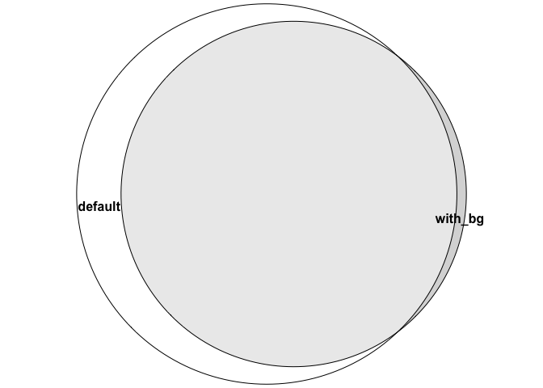

```r
diff_gene = df$gene[df$padj < 0.01]
diff_gene = convert_to_entrez_id(diff_gene)
tb = enricher(gene = diff_gene, TERM2GENE = map)

tb_with_bg = enricher(gene = diff_gene, TERM2GENE = map, universe = convert_to_entrez_id(df$gene))

lt = list(default = tb$ID[tb$p.adjust < 0.01],
    with_bg = tb_with_bg$ID[tb_with_bg$p.adjust < 0.01])

library(eulerr)
plot(euler(lt))
```

You can use a Venn diagram or a Euler (via package **eulerr**) to compare.

You can also compare the selection of cutoffs for adjusted p-values for diff genes:

1. set fdr < 0.05
2. set fdr < 0.01
3. select top 500 most significant genes
4. select top 1000 most significant genes

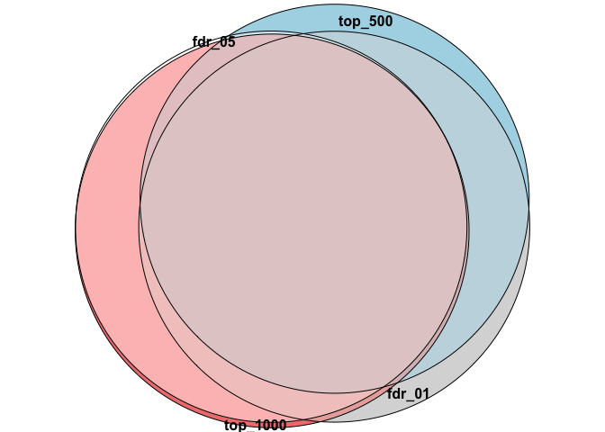

```r
diff_gene = df$gene[df$padj < 0.05]
diff_gene = convert_to_entrez_id(diff_gene)
tb1 = enricher(gene = diff_gene, TERM2GENE = map)

diff_gene = df$gene[df$padj < 0.01]
diff_gene = convert_to_entrez_id(diff_gene)
tb2 = enricher(gene = diff_gene, TERM2GENE = map)

diff_gene = df$gene[order(df$padj)[1:500]]
diff_gene = convert_to_entrez_id(diff_gene)
tb3 = enricher(gene = diff_gene, TERM2GENE = map)

diff_gene = df$gene[order(df$padj)[1:1000]]
diff_gene = convert_to_entrez_id(diff_gene)
tb4 = enricher(gene = diff_gene, TERM2GENE = map)

lt = list(fdr_05 = tb1$ID[tb1$p.adjust < 0.01],
          fdr_01 = tb2$ID[tb2$p.adjust < 0.01],
          top_500 = tb3$ID[tb3$p.adjust < 0.01],
          top_1000 = tb4$ID[tb4$p.adjust < 0.01])

plot(euler(lt))
```

### Compare hypergeometric distribution and chi-square test

Write a function `ora_test()` which accepts three arguments:

- diff gene
- bg gene
- genes in the set

The function first construct the 2x2 contigency table and calculated p-values from hypergeometric distribution and chi-square test (`day1_ora_example.html` might be helpful for you).

```r
ora_test = function(diff_gene, bg_gene, gene_set) {
    # number of #DE
    n10 = length(diff_gene)
    n01 = length(gene_set)
    n = length(bg_gene)

    # #DE in the set
    n11 = length(intersect(diff_gene, gene_set))
    n21 = n01 - n11
    n12 = n10 - n11

    # #non-DE
    n20 = n - n10

    # gene not in the set
    n02 = n - n01

    n22 = n02 - n12

    # hypergeometric distribution
    p1 = 1 - phyper(n11-1, n10, n20, n01)
    # chi-square test
    t = chisq.test(matrix(c(n11, n21, n12, n22), nrow = 2), correct = FALSE)

    # print(matrix(c(n11, n21, n12, n22), nrow = 2))
    p2 = t$p.value

    var = c(p1, p2)
    names(var) = c("hyper", "chisq")

    return(var)
}
```

```r
load("demo_ora.RData")
# two gene lists
# - diff_gene diff gene list
# - bg_gene background gene list
```

```r
library(msigdbr)
gs_db = msigdbr(category = "C2", subcategory = "CP:KEGG")
gene_set = gs_db$gene_symbol[gs_db$gs_name == "KEGG_ABC_TRANSPORTERS"]
```

```r
# - diff_gene
# - bg_gene
# - gene_set

ora_test(diff_gene, bg_gene, gene_set)
```

```
##        hyper        chisq
## 0.0042149566 0.0002495194
```

```r
# test the effect of imcomplete gene set
p = numeric(100)
for(i in 1:100) {
  p[i] = ora_test(diff_gene, bg_gene, sample(gene_set, 0.8*length(gene_set)))[1]
}
```

[output not shown]

[output cut: 244 more lines]

[output not shown]

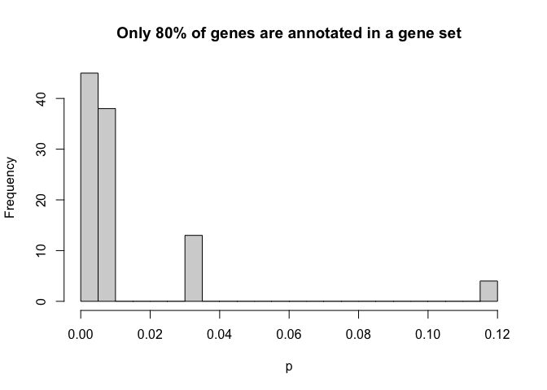

```r
hist(p, nc = 20, main = "Only 80% of genes are annotated in a gene set")
```

The function returns a vector of length two: p-values from the two test.

Note: the object returned by `msigdbr()` is a data frame where each row contains mapping of a single gene to a single gene set. You need to convert it into a list where each element in the list is a vector of genes in every gene set (use `split()` function).